# Credit Card Fraud Detection

In this project, the goal is to come up with a binary classification model to detect whether a credit card transaction is likely to be fraud or not.  
This project will focus on data cleaning and model building. To approach the missing data, we will observe the percentage of missing data of each feature and choose different methods and handling such data based on the volume that is missing. We will also compare various binary classification models, mainly using the F1 score as a metric to filter out the best model to use for this problem. We will compare the following models:

- K-Nearest Neighbors
- Decision Tree
- Random Forest
- Logistic Regression

SMOTE and Random Undersampling techniques are used to account for the unbalanced dataset to allow for better quality training data and to ensure the results produced by the models are accurate. Furthermore, we will use an encoder to process non-numeric data so that the models can read and process the information.

### Summary of Results

After comparing various classification models, the best model for this problem is the Random Forest Classifier, which can successfully classify a credit card transaction with an F1 score of 0.8.  
For more details on how the model is built, please refer to the full project below.

### Dataset

To avoid time constraints for obtaining a large volume of data and confidentiality issues due to the nature of credit card transactions, we will use an existing dataset for this project's purpose. The data is publicly available on [Kaggle](https://www.kaggle.com/mishra5001/credit-card), containing over 300,000 credit card transactions with over 100 features.  
In this project, we will use two datasets, the application data and the previous application dataset. We will combine these two datasets by the transaction ID and use the combined dataset for exploration and model training.

```python
# load packages
import pandas as pd
import numpy as np
import seaborn as sns
import matplotlib.pyplot as plt
```

```python
# read in application dataset
data = pd.read_csv("application_data.csv")
```

```python
# read in previous application dataset
data2 = pd.read_csv("previous_application.csv")
```

```python
# drop duplicated columns in previous application dataset
to_drop = ['NAME_CONTRACT_TYPE', 'NAME_TYPE_SUITE', 'AMT_GOODS_PRICE', 'AMT_ANNUITY',
           'AMT_CREDIT', 'WEEKDAY_APPR_PROCESS_START', 'HOUR_APPR_PROCESS_START']
data2.drop(to_drop, axis=1, inplace=True)
# join application and previous application dataset
data = pd.merge(data, data2, left_on='SK_ID_CURR', right_on='SK_ID_CURR')
```

```python
data
```

|  | SK_ID_CURR | TARGET | NAME_CONTRACT_TYPE | CODE_GENDER | FLAG_OWN_CAR | FLAG_OWN_REALTY | CNT_CHILDREN | AMT_INCOME_TOTAL | AMT_CREDIT | AMT_ANNUITY | ... | NAME_SELLER_INDUSTRY | CNT_PAYMENT | NAME_YIELD_GROUP | PRODUCT_COMBINATION | DAYS_FIRST_DRAWING | DAYS_FIRST_DUE | DAYS_LAST_DUE_1ST_VERSION | DAYS_LAST_DUE | DAYS_TERMINATION | NFLAG_INSURED_ON_APPROVAL |
| --- | --- | --- | --- | --- | --- | --- | --- | --- | --- | --- | --- | --- | --- | --- | --- | --- | --- | --- | --- | --- | --- |
| 0 | 100002 | 1 | Cash loans | M | N | Y | 0 | 202500.0 | 406597.5 | 24700.5 | ... | Auto technology | 24.0 | low_normal | POS other with interest | 365243.0 | -565.0 | 125.0 | -25.0 | -17.0 | 0.0 |
| 1 | 100003 | 0 | Cash loans | F | N | N | 0 | 270000.0 | 1293502.5 | 35698.5 | ... | XNA | 12.0 | low_normal | Cash X-Sell: low | 365243.0 | -716.0 | -386.0 | -536.0 | -527.0 | 1.0 |
| 2 | 100003 | 0 | Cash loans | F | N | N | 0 | 270000.0 | 1293502.5 | 35698.5 | ... | Furniture | 6.0 | middle | POS industry with interest | 365243.0 | -797.0 | -647.0 | -647.0 | -639.0 | 0.0 |
| 3 | 100003 | 0 | Cash loans | F | N | N | 0 | 270000.0 | 1293502.5 | 35698.5 | ... | Consumer electronics | 12.0 | middle | POS household with interest | 365243.0 | -2310.0 | -1980.0 | -1980.0 | -1976.0 | 1.0 |
| 4 | 100004 | 0 | Revolving loans | M | Y | Y | 0 | 67500.0 | 135000.0 | 6750.0 | ... | Connectivity | 4.0 | middle | POS mobile without interest | 365243.0 | -784.0 | -694.0 | -724.0 | -714.0 | 0.0 |
| ... | ... | ... | ... | ... | ... | ... | ... | ... | ... | ... | ... | ... | ... | ... | ... | ... | ... | ... | ... | ... | ... |
| 1413696 | 456255 | 0 | Cash loans | F | N | N | 0 | 157500.0 | 675000.0 | 49117.5 | ... | XNA | 24.0 | middle | Cash X-Sell: middle | 365243.0 | -618.0 | 72.0 | -558.0 | -528.0 | 1.0 |
| 1413697 | 456255 | 0 | Cash loans | F | N | N | 0 | 157500.0 | 675000.0 | 49117.5 | ... | Connectivity | 0.0 | XNA | Card Street | NaN | NaN | NaN | NaN | NaN | NaN |
| 1413698 | 456255 | 0 | Cash loans | F | N | N | 0 | 157500.0 | 675000.0 | 49117.5 | ... | XNA | 60.0 | low_normal | Cash Street: low | NaN | NaN | NaN | NaN | NaN | NaN |
| 1413699 | 456255 | 0 | Cash loans | F | N | N | 0 | 157500.0 | 675000.0 | 49117.5 | ... | XNA | 36.0 | low_normal | Cash X-Sell: low | 365243.0 | -756.0 | 294.0 | -66.0 | -64.0 | 0.0 |
| 1413700 | 456255 | 0 | Cash loans | F | N | N | 0 | 157500.0 | 675000.0 | 49117.5 | ... | Connectivity | 6.0 | high | POS mobile with interest | 365243.0 | -469.0 | -319.0 | -409.0 | -400.0 | 0.0 |

1413701 rows × 151 columns

```python
print("The combined dataset has a total of {} rows and {} columns.".format(data.shape[0], data.shape[1]))
```

```
The combined dataset has a total of 1413701 rows and 151 columns.
```

## Data Cleaning

After observation, some of the entries are XNA. These values will be replaced with NA values in the DataFrame.

For this dataset, I will set a threshold of 30% to the percentage of missing values.

- Any columns with 30% or more missing values will be removed from the DataFrame.
- Columns with less than 1% of missing values will have those particular rows removed.
- All other columns with missing values will be looked at individually to decide how to fill the missing data.

```python
data = data.replace('XNA', np.nan)
```

```python
def missing_percentage():
    data_size = len(data) # length of dataframe
    missing = data.isnull().sum() # number of missing values per column
    missing_percentage = (missing/data_size)*100
    missing_percentage = missing_percentage[missing_percentage>0] # filter out columns with no missing values
    return missing_percentage
```

```python
# store the missing percentage of the dataframe columns in a variable
missing_data = missing_percentage()
```

### Columns With Less Than 1% Missing Data

Below is a list of columns that have less than 1% of missing data. I will remove the rows with missing values for these columns since the number of affected rows is small.

```python
# show columns with less than 1% missing data
na1_tab = missing_data[missing_data<1]
na1_tab
```

```
CODE_GENDER                 0.003890
AMT_ANNUITY                 0.006578
AMT_GOODS_PRICE             0.085449
NAME_TYPE_SUITE             0.249416
EXT_SOURCE_2                0.128811
OBS_30_CNT_SOCIAL_CIRCLE    0.222536
DEF_30_CNT_SOCIAL_CIRCLE    0.222536
OBS_60_CNT_SOCIAL_CIRCLE    0.222536
DEF_60_CNT_SOCIAL_CIRCLE    0.222536
CODE_REJECT_REASON          0.309684
NAME_CLIENT_TYPE            0.109146
PRODUCT_COMBINATION         0.022140
dtype: float64
```

```python
# get index of missing data and remove these rows
na1_index = missing_data[missing_data<1].index
na1_data = data[na1_index]
na1_data = na1_data[pd.isnull(na1_data[na1_index]).any(axis = 1)]
index = na1_data.index
data = data.drop(index)
```

```python
print("{} rows are removed due to missing data.".format(len(index)))
```

```
14820 rows are removed due to missing data.
```

### Columns With 30% or More Missing Data

Below is a list of columns that have 30% or more missing data. I will remove these columns from the DataFrame.

```python
# show columns with 30% or more missing data
na30_data = missing_data[missing_data>=30]
```

```python
na30_data
```

```
OWN_CAR_AGE                  66.294499
OCCUPATION_TYPE              32.367523
EXT_SOURCE_1                 56.366870
APARTMENTS_AVG               50.364115
BASEMENTAREA_AVG             58.308511
                               ...
DAYS_FIRST_DUE               39.690571
DAYS_LAST_DUE_1ST_VERSION    39.690571
DAYS_LAST_DUE                39.690571
DAYS_TERMINATION             39.690571
NFLAG_INSURED_ON_APPROVAL    39.690571
Length: 66, dtype: float64
```

```python
col_names = na30_data.index
```

```python
data = data.drop(col_names, axis = 1)
```

```python
# get data of columns with missing data between 1% to 30%
na_30 = missing_data[(missing_data<30) & (missing_data>1)]
na_30_data = data[na_30.index]
```

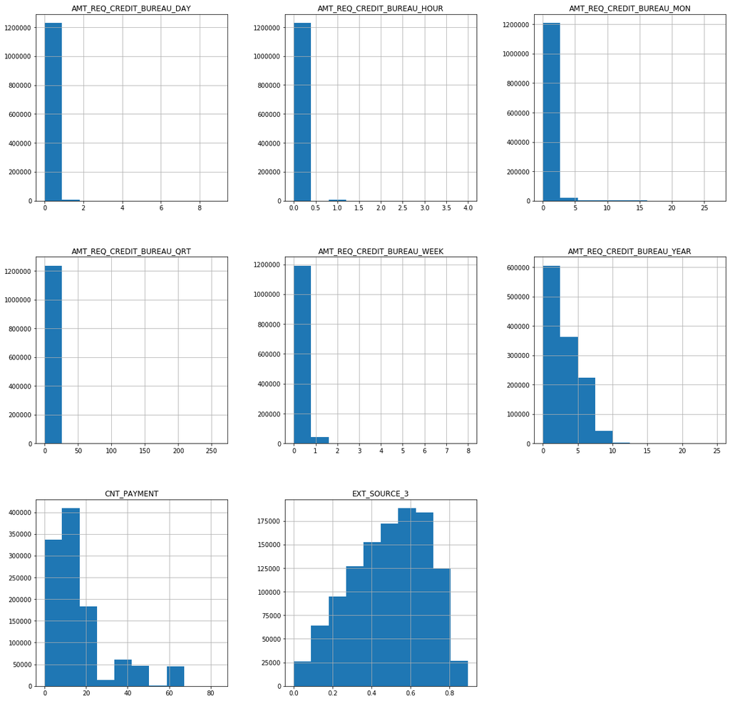

```python
# show each column as histogram plot
na_30_data.hist(figsize = (20, 20))
plt.show()
```

From the dataset description, the columns with a prefix of AMT_REQ_CREDIT_BUREAU represent the number of enquiries to Credit Bureau about the client one hour, day, week, month, year and qrt before application. Thus, we will treat these columns as categorical data instead of float. Furthermore, we will replace the missing values by the mode of each respective column. </br> EXT_SOURCE_3 is normally distribution so we will fill the missing value with the mean.

```python
# fill the NA values in this column with mode value
def fill_mode(col_name):
    data[col_name] = data[col_name].fillna(data[col_name].mode()[0])
```

```python
# columns with missing data
cols = ['AMT_REQ_CREDIT_BUREAU_HOUR', 'AMT_REQ_CREDIT_BUREAU_DAY', 'AMT_REQ_CREDIT_BUREAU_WEEK', 'AMT_REQ_CREDIT_BUREAU_MON',
        'AMT_REQ_CREDIT_BUREAU_YEAR', 'AMT_REQ_CREDIT_BUREAU_QRT', 'CNT_PAYMENT']

# fill with mode
for col in cols:
    fill_mode(col)

# fill with mean
data['EXT_SOURCE_3'] = data['EXT_SOURCE_3'].fillna(data['EXT_SOURCE_3'].mean())
```

```python
data = data.drop(['SK_ID_CURR'], axis = 1)
```

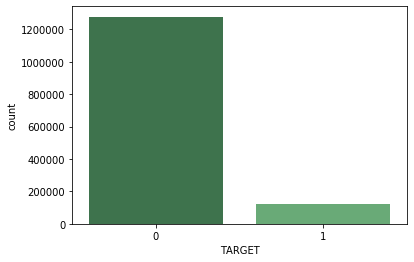

```python
# plot distribution of the target column
sns.countplot(x= "TARGET", data = data, palette = "Greens_d")
```

Our target variable is highly unbalanced, with a significantly higher amount in non-fraud transactions than ones that are a fraud. We will need to account for this later by oversampling the minority class and undersampling the majority class in the following section when we train the classification model.

## Training the Models

Before running the machine learning models, we will first use the LabelEncoder to encode non-numeric columns into numeric.We will split the dataset into a 3:7 ratio of test and train set.  
SMOTE and random under-sampling will be applied to the minority and majority class of the training set because it is imbalanced. Usually, a balanced dataset will use the accuracy score as a measure of performance for the models. However, since this dataset is heavily imbalanced, we will use the f1 score to measure model performance instead.

```python
# load machine learning packages
from sklearn.metrics import precision_score, recall_score, f1_score
from sklearn.linear_model import LogisticRegression
from sklearn.tree import DecisionTreeClassifier
from sklearn.neighbors import KNeighborsClassifier
from sklearn.ensemble import RandomForestClassifier
from sklearn.model_selection import train_test_split
from sklearn.preprocessing import LabelEncoder
from imblearn.over_sampling import SMOTE
from imblearn.under_sampling import RandomUnderSampler
from imblearn.pipeline import Pipeline
from collections import Counter
import warnings
warnings.filterwarnings("ignore")
```

```python
# initialize encoder
enc = LabelEncoder()

# columns to encode
cols = ['WEEKDAY_APPR_PROCESS_START', 'NAME_CONTRACT_TYPE', 'CODE_GENDER', 'FLAG_OWN_CAR', 'FLAG_OWN_REALTY',
        'FLAG_LAST_APPL_PER_CONTRACT']

# string columns to encode
str_cols = ['NAME_TYPE_SUITE', 'ORGANIZATION_TYPE', 'NAME_HOUSING_TYPE', 'NAME_CLIENT_TYPE', 'NAME_FAMILY_STATUS',
            'NAME_EDUCATION_TYPE', 'NAME_INCOME_TYPE', 'PRODUCT_COMBINATION', 'CHANNEL_TYPE', 'NAME_CONTRACT_STATUS',
           'CODE_REJECT_REASON', 'NAME_PORTFOLIO']

# encode columns
for col in cols:
    data[col] = enc.fit_transform(data[col])

# encode string columns
for col in str_cols:
    data[col] = enc.fit_transform(data[col].astype(str))
```

```python
# split dataset into train and test set,
# using the target column as our target and the rest of the columns for predicting
X = data.drop(['TARGET'], axis = 1)
target = data['TARGET']
X_train, X_test, Y_train, Y_test = train_test_split(X, target, test_size= 0.3, random_state = 21)
counter1 = Counter(Y_train)
```

```python
# apply oversampling to the miniority class and undersampling to the magority class
over_sample = SMOTE(sampling_strategy= 'minority', random_state = 21)
under_sample = RandomUnderSampler(sampling_strategy= 'majority', random_state = 21)
steps = [('over', over_sample), ('under', under_sample)]
pipeline = Pipeline(steps = steps)

X_train, Y_train = pipeline.fit_resample(X_train, Y_train)
```

```python
counter2 = Counter(Y_train)
# print class distribution before and after transformation
print("Pre transformation: ", counter1)
print("Post transformation: ", counter2)
```

```
Pre transformation:  Counter({0: 894302, 1: 84914})
Post transformation:  Counter({0: 894302, 1: 894302})
```

### Model Selection

In this section we will fit the transformed training data with the following models:

- K-Nearest Neighbors
- Decision Tree
- Random Forest
- Logistic Regression

We will compute each model's precision, recall, and F1 score and organize them in a table. One of these models will be chosen as the best model for our problem. The decision will be made based on the precision, recall and F1 score of the model, emphasizing the f1 score.

```python
# list of models to fit
models = [KNeighborsClassifier(), DecisionTreeClassifier(), RandomForestClassifier(), LogisticRegression()]
# initialize comparison table
table = pd.DataFrame(columns = ['Model', 'Precision', 'Recall', 'F1 Score'])
# container to store features of the best model
best_feature = []
cur_score = 0
index = 0
for model in models:
    cur_model = model
    # fit and get model information
    model_name = model.__class__.__name__
    model_fit = cur_model.fit(X_train, Y_train)
    model_predict = model_fit.predict(X_test)
    precision = precision_score(Y_test, model_predict)
    recall = recall_score(Y_test, model_predict)
    f1 = f1_score(Y_test, model_predict)
    # update highest f1 score and model features
    if (f1 > cur_score) and (model_name!='KNeighborsClassifier'):
        cur_score = f1
        best_feature = cur_model.feature_importances_
    # fill current row
    table.loc[index] = model_name, precision, recall, f1
    index += 1
```

```python
table
```

|  | Model | Precision | Recall | F1 Score |
| --- | --- | --- | --- | --- |
| 0 | KNeighborsClassifier | 0.106293 | 0.363785 | 0.164517 |
| 1 | DecisionTreeClassifier | 0.656111 | 0.785249 | 0.714895 |
| 2 | RandomForestClassifier | 0.984280 | 0.681464 | 0.805347 |
| 3 | LogisticRegression | 0.112291 | 0.590193 | 0.188683 |

### Feature Importances

```python
# filter with top 10 features with the highest importance
most_features = best_feature[-10:]
```

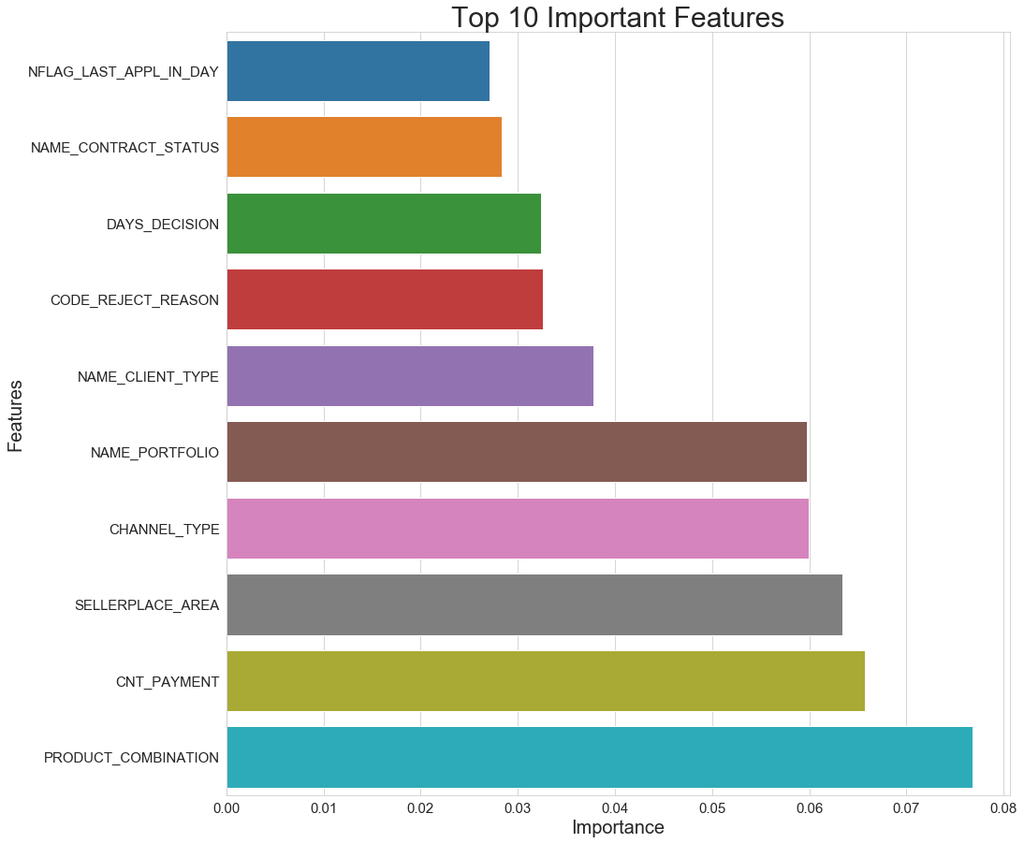

```python
# disaply above data as bar graph
sns.set_style('whitegrid')
plt.figure(figsize=(15, 15))
most_feature_plot = sns.barplot(x=most_features, y=X.columns[-10:])
most_feature_plot.set_title('Top 10 Important Features', fontsize = 30)
most_feature_plot.set_ylabel('Features', fontsize = 20)
most_feature_plot.set_xlabel('Importance', fontsize = 20)
most_feature_plot.tick_params(labelsize = 15)
```

## Conclusion and Next Steps

Using SMOTE and undersampling methods, we can reduce the impact of imbalanced data on our training models.  
After comparing four different binary classification models(K-Neighbors, Decision Tree, Random Forest and Logistic Regression), we found that the model that performed the best amongst the four models is the Random Forest Classifier with an F1 score of 0.8.

We found out that general information on a client does not tell much about whether the transaction could be fraud or not. On the other hand, information related to the client's previous applications and the seller area are the best features in identifying a transaction's fraudulence.

To further improve the model, we could use Grid Search to find the Random Forest Classifier's most optimal parameters that will enhance the current model's performance.